# Exploratory Data Analysis for Natural Language Processing

# Introduction

The purpose of this report is to detail initial exploratory data analysis of a corpus of English text obtained from some Twitter feeds, blog posts, and news articles. We will analyze the makeup of the source corpora, and we will describe the tokenization of (smaller) sampled data sets from the original corpus.

# Exploratory Data Analysis

The corpus is set of large text files consisting of lines of text separated by carriage return, or newline, characters. The size of the data set is

```
## [1] "File en_US.twitter.txt has size 316037624 bytes containing 2360148 lines of text."
## [1] "File en_US.news.txt has size 261759312 bytes containing 1010242 lines of text."
## [1] "File en_US.blogs.txt has size 260564584 bytes containing 899288 lines of text."
```

Since this data set is so large, we will not count the number of words, or n-grams. Instead, we will generate a smaller data set using binomial sampling with p=.025 (2.5%), followed by combining the three sampled files into one file. Given the size of the original data set, this sampled data set adequately represents the population. Thus, our exploratory data analysis will consist of a deep dive into the sampled data.

## Tokenization of the Sampled Dataset

Following this tokenization procedure, we found all of the n-grams (n=1,2,3,4) and tallied the total count of each type of n-gram. The following table shows the total counts of n-grams:

| Dataset | Total.Words | Total.Two.Grams | Total.Three.Grams | Total.Four.Grams |
| --- | --- | --- | --- | --- |
| Blogs | 933322 | 910752 | 888879 | 867051 |
| News | 848769 | 823694 | 799188 | 773815 |
| Twitter | 745085 | 687805 | 630217 | 573452 |
| Combined | 2527176 | 2422251 | 2318284 | 2214318 |

Additionally, we have the following charts that show which n-grams are most frequent:

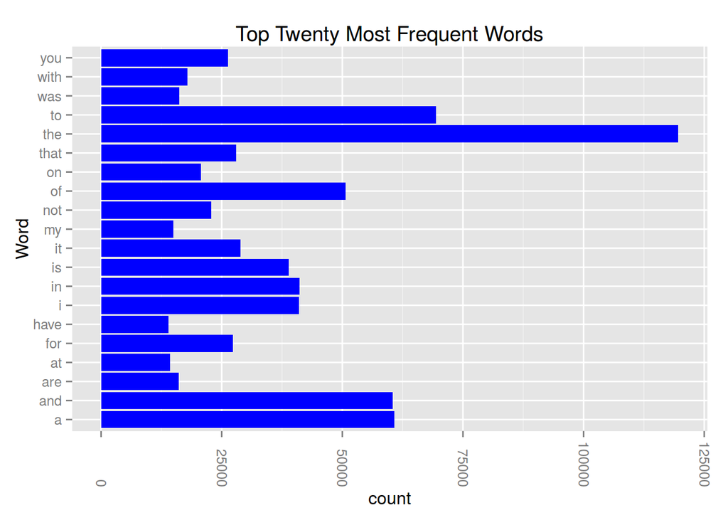

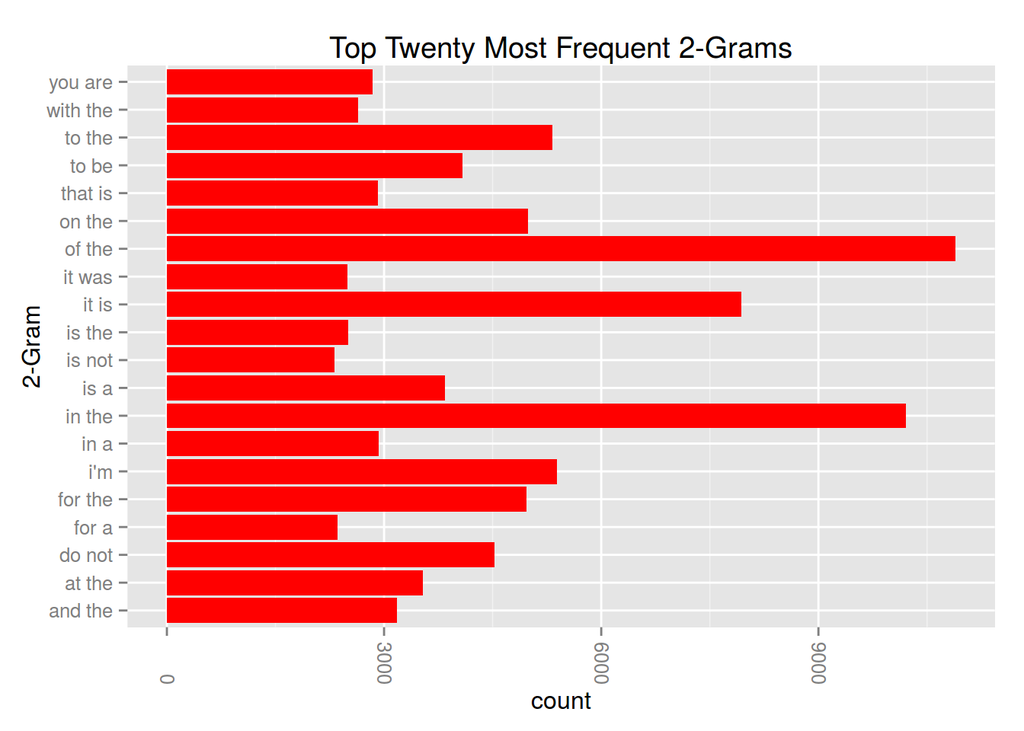

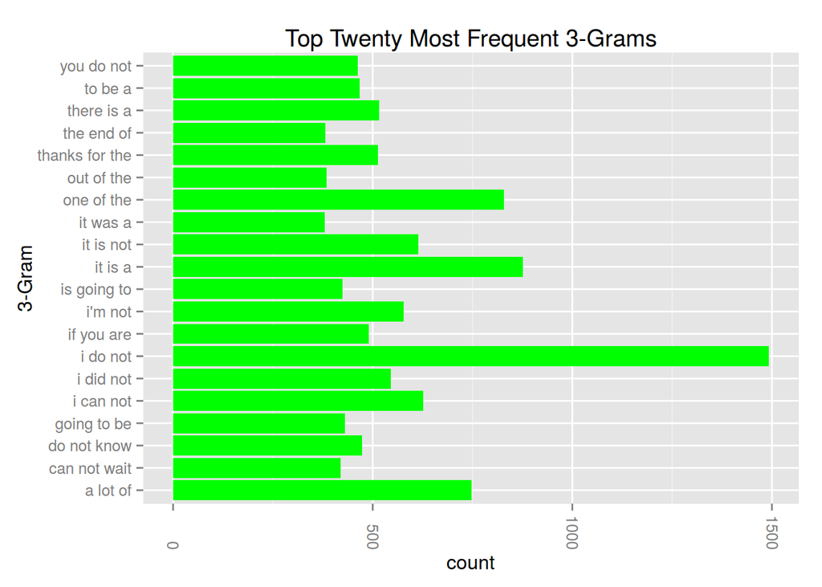

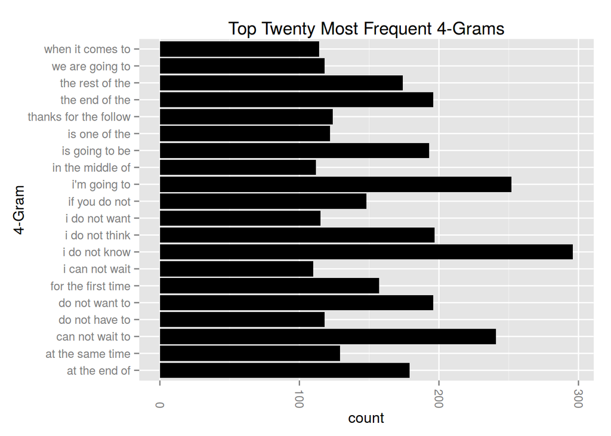

From these charts, we see that the higher the order of the n-gram, the flatter the distribution, i.e., the peak count decreases as n increases.

# Prediction Modeling

To develop the language prediction model, we will develop a Markov chain model which will use n-grams to predict the next word in the sequence. From the sampled data above, we will be able to compute the probability of each word and n-gram (up to n=4). However, we will need to compress the data so that the size of the model becomes useable. Some techniques for data compression are

- Stemming,
- Removing stop words, and
- Decreasing the sample size.

Each of these techniques will be investigated to determine their effectiveness for data compression and prediction accuracy. For the probability model, we will most likely use Katz’ back-off model with Good-Turing smoothing and cross-validation, which will drive the Markov prediction algorithm.